# LiveSessionUNit11

Daniel Davieau

March 27, 2018

```r
#Live Session 12 demo
rm(list=ls())
library("dygraphs")
library("forecast")
#read, convert and display births timeseries dataset
births <- scan("http://robjhyndman.com/tsdldata/data/nybirths.dat")
births <- ts(births, frequency = 12, start = c(1946, 1))  #frequency =12 because its a monthly dataset, 1=yearly, 4=quarterly
births
```

```
##         Jan    Feb    Mar    Apr    May    Jun    Jul    Aug    Sep    Oct
## 1946 26.663 23.598 26.931 24.740 25.806 24.364 24.477 23.901 23.175 23.227
## 1947 21.439 21.089 23.709 21.669 21.752 20.761 23.479 23.824 23.105 23.110
## 1948 21.937 20.035 23.590 21.672 22.222 22.123 23.950 23.504 22.238 23.142
## 1949 21.548 20.000 22.424 20.615 21.761 22.874 24.104 23.748 23.262 22.907
## 1950 22.604 20.894 24.677 23.673 25.320 23.583 24.671 24.454 24.122 24.252
## 1951 23.287 23.049 25.076 24.037 24.430 24.667 26.451 25.618 25.014 25.110
## 1952 23.798 22.270 24.775 22.646 23.988 24.737 26.276 25.816 25.210 25.199
## 1953 24.364 22.644 25.565 24.062 25.431 24.635 27.009 26.606 26.268 26.462
## 1954 24.657 23.304 26.982 26.199 27.210 26.122 26.706 26.878 26.152 26.379
## 1955 24.990 24.239 26.721 23.475 24.767 26.219 28.361 28.599 27.914 27.784
## 1956 26.217 24.218 27.914 26.975 28.527 27.139 28.982 28.169 28.056 29.136
## 1957 26.589 24.848 27.543 26.896 28.878 27.390 28.065 28.141 29.048 28.484
## 1958 27.132 24.924 28.963 26.589 27.931 28.009 29.229 28.759 28.405 27.945
## 1959 26.076 25.286 27.660 25.951 26.398 25.565 28.865 30.000 29.261 29.012
##         Nov    Dec
## 1946 21.672 21.870
## 1947 21.759 22.073
## 1948 21.059 21.573
## 1949 21.519 22.025
## 1950 22.084 22.991
## 1951 22.964 23.981
## 1952 23.162 24.707
## 1953 25.246 25.180
## 1954 24.712 25.688
## 1955 25.693 26.881
## 1956 26.291 26.987
## 1957 26.634 27.735
## 1958 25.912 26.619
## 1959 26.992 27.897
```

```r
#read, convert and display gift shop dataset
gift <- scan("http://robjhyndman.com/tsdldata/data/fancy.dat")
gift<- ts(gift, frequency=12, start=c(1987,1))
gift
```

```
##            Jan       Feb       Mar       Apr       May       Jun       Jul
## 1987   1664.81   2397.53   2840.71   3547.29   3752.96   3714.74   4349.61
## 1988   2499.81   5198.24   7225.14   4806.03   5900.88   4951.34   6179.12
## 1989   4717.02   5702.63   9957.58   5304.78   6492.43   6630.80   7349.62
## 1990   5921.10   5814.58  12421.25   6369.77   7609.12   7224.75   8121.22
## 1991   4826.64   6470.23   9638.77   8821.17   8722.37  10209.48  11276.55
## 1992   7615.03   9849.69  14558.40  11587.33   9332.56  13082.09  16732.78
## 1993  10243.24  11266.88  21826.84  17357.33  15997.79  18601.53  26155.15
##            Aug       Sep       Oct       Nov       Dec
## 1987   3566.34   5021.82   6423.48   7600.60  19756.21
## 1988   4752.15   5496.43   5835.10  12600.08  28541.72
## 1989   8176.62   8573.17   9690.50  15151.84  34061.01
## 1990   7979.25   8093.06   8476.70  17914.66  30114.41
## 1991  12552.22  11637.39  13606.89  21822.11  45060.69
## 1992  19888.61  23933.38  25391.35  36024.80  80721.71
## 1993  28586.52  30505.41  30821.33  46634.38 104660.67
```

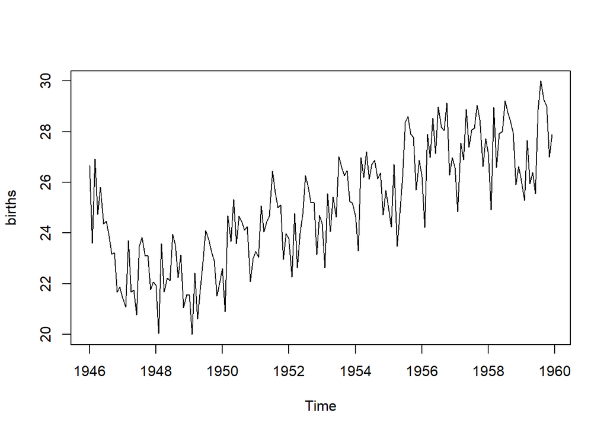

```r
#plot births and gift timeseries - both have seasonal components
plot(births)  #additive or multiplicative?
```

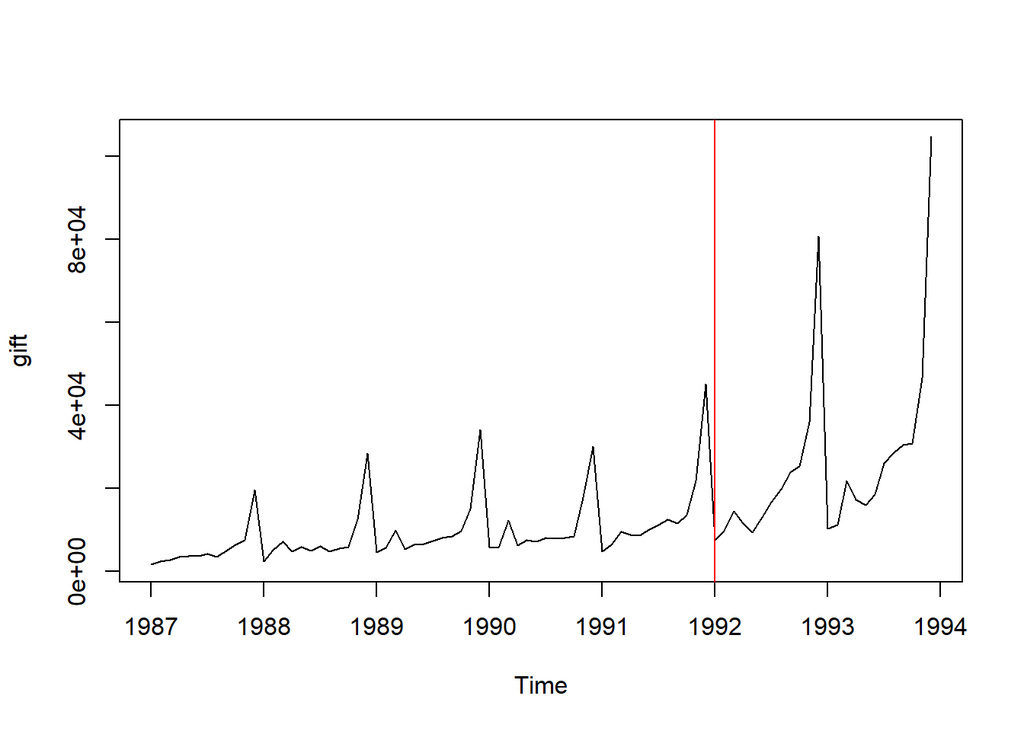

```r
plot(gift)    #additive or multiplicative?
abline(v=1992, col="red")
```

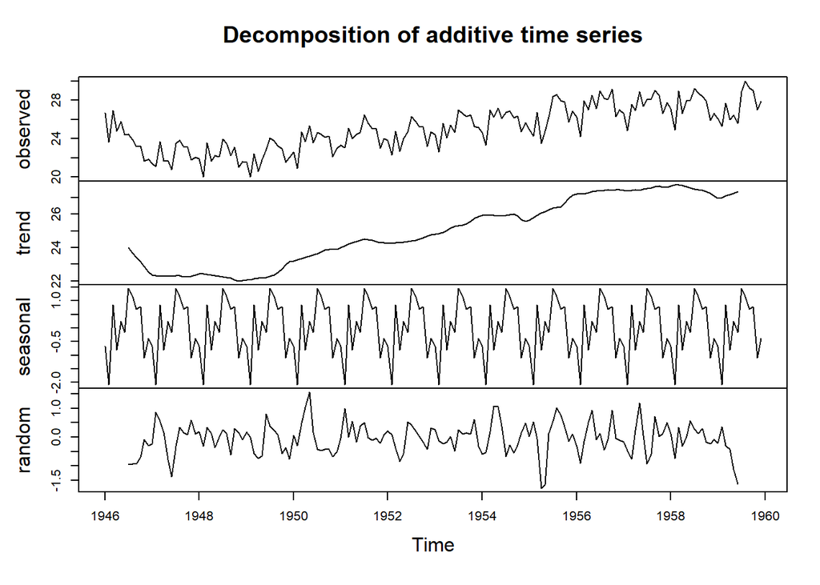

```r
#decompose seasonal data
birthsComp <- decompose(births, type="add")
plot(birthsComp)
```

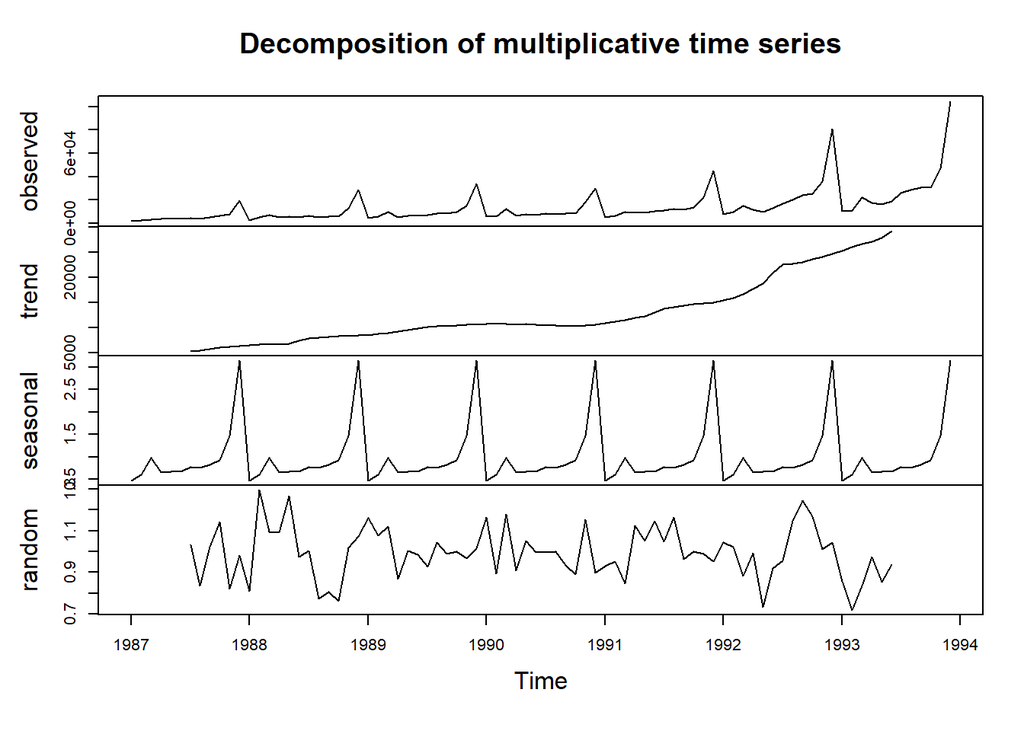

```r
giftComp <- decompose(gift, type="mult")
plot(giftComp)
```

```r
#HoltWinters filtering on births
birthsHW <- HoltWinters(births)
birthsHW
```

```
## Holt-Winters exponential smoothing with trend and additive seasonal component.
##
## Call:
## HoltWinters(x = births)
##
## Smoothing parameters:
##  alpha: 0.4823655
##  beta : 0.02988495
##  gamma: 0.563186
##
## Coefficients:
##            [,1]
## a   28.04366357
## b    0.04199921
## s1  -0.78546221
## s2  -2.19944507
## s3   0.87813012
## s4  -0.65164728
## s5   0.63427267
## s6   0.21182821
## s7   2.23177191
## s8   2.17167733
## s9   1.52077678
## s10  1.16900861
## s11 -0.97500043
## s12 -0.18636055
```

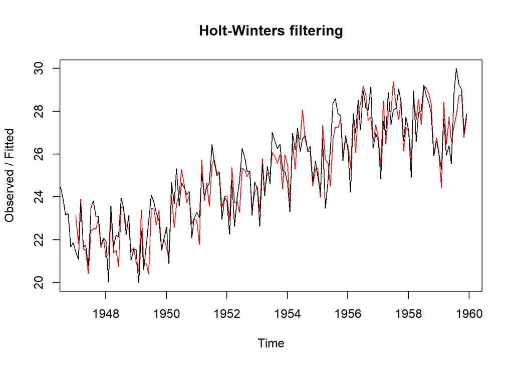

```r
plot(birthsHW)
```

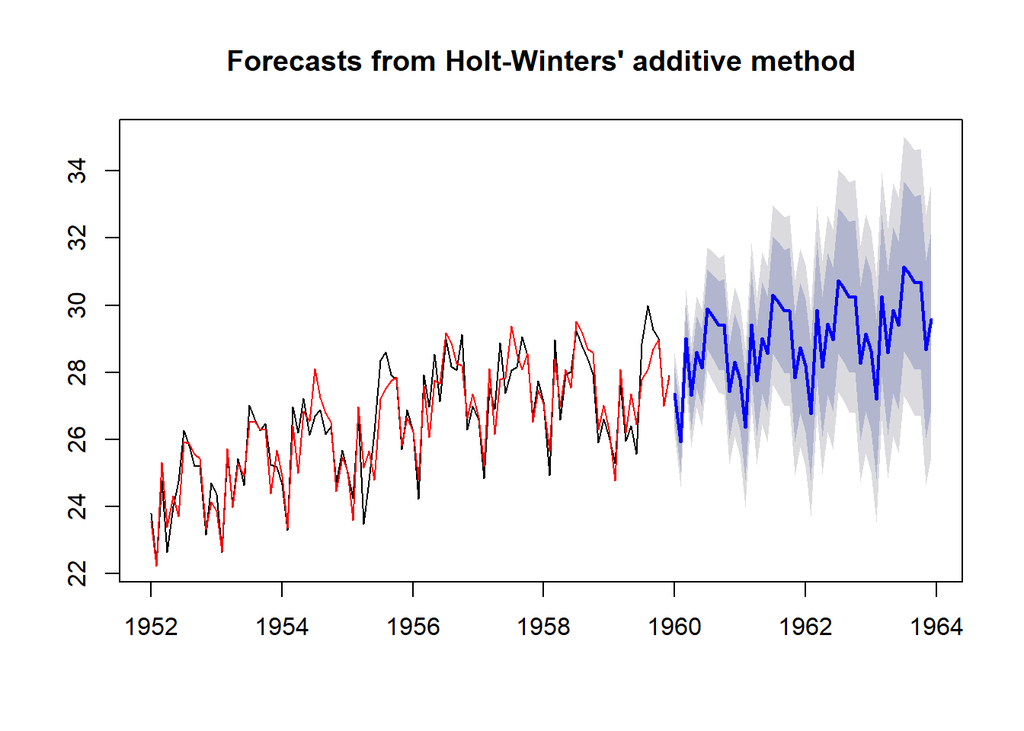

```r
#forecast for next 48 months
#start from 1952
#blue line: actual prediction, dark gray: 80% confidence interval, light gray: 95% confidence interval
birthsSubset<-window(births, start=1952)
birthsF5 <- hw(birthsSubset, initial="optimal", h=48)
plot(birthsF5)
lines(fitted(birthsF5), col="red")
```

```r
#dygraphs
dygraph(birthsSubset, main="Birth rates", ylab="Births", xlab="Year") %>%
  dyRangeSelector(height=100) %>%
  dyShading(from = "1955-1-1", to = "1956-1-1", color = "#FFE6E6") %>%
  dyShading(from = "1959-1-1", to = "1960-1-1", color = "#CCEBD6")
```

[interactive chart not shown]

1. Using the maxtemp dataset granted by loading fpp2, there are maximum annual temperature data in Celsius. For more information, use help(maxtemp). To see what you’re looking at, execute the command in ‘Examples’ in the help document.
2. We are only concerned with information after 1990. Please eliminate unwanted information or subset information we care about.
3. Utilize SES to predict the next five years of maximum temperatures in Melbourne. Plot this information, including the prior information and the forecast. Add the predicted value line across 1990 present as a separate line, preferably blue. So, to review, you should have your fit, the predicted value line overlaying it, and a forecast through 2021, all on one axis. Find the AICc of this fitted model. You will use that information later.
4. Now use a damped Holt’s linear trend to also predict out five years. Make sure initial=“optimal.” As above, create a similar plot to 1C, but use the Holt fit instead.
5. Compare the AICc of the ses() and holt() models. Which model is better here?

```r
#In this exercise, we will use Temperature data
library("fpp2")
```

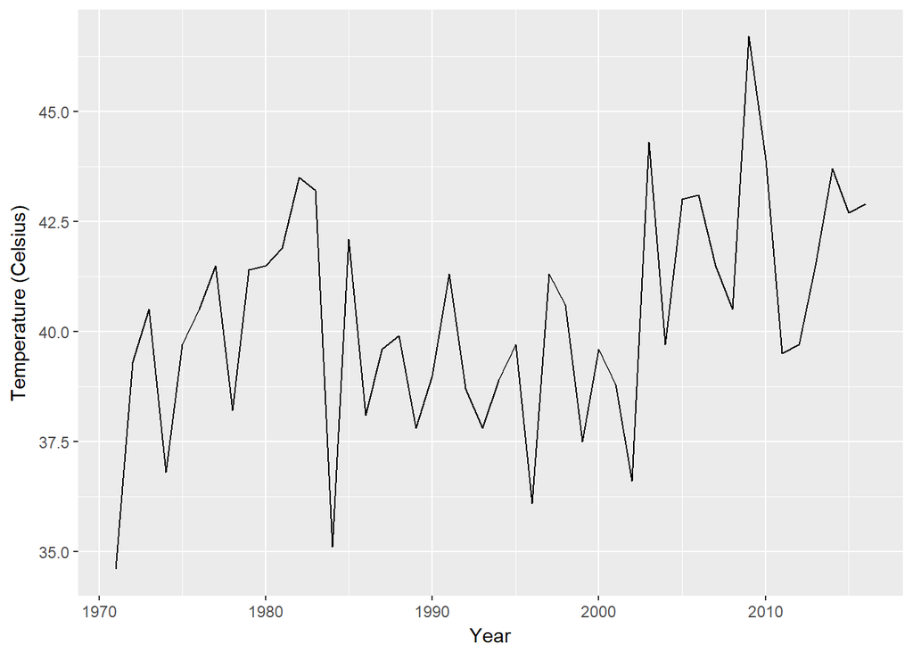

```r
library("dygraphs")
library("xts")
autoplot(maxtemp, xlab="Year", ylab="Temperature (Celsius)")
```

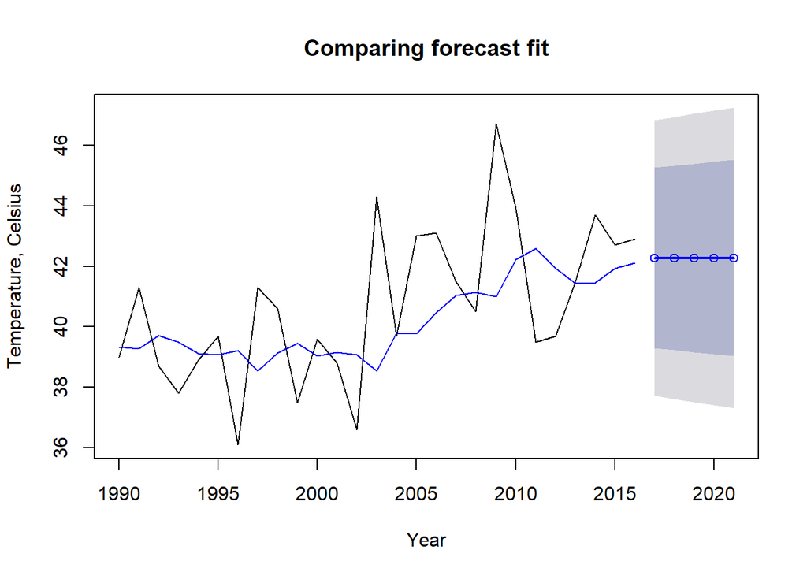

```r
ts<-window(maxtemp, start=1990)

# Use SES
fit<-ses(ts, h=5)

# Comparing Forecast Fit
plot(fit,ylab="Temperature, Celsius", xlab= "Year", main="Comparing forecast fit")
lines(fitted(fit), col="blue")
lines(fit$mean, col="blue", type="o")
```

```r
# Finding AICc
fit$model
```

```
## Simple exponential smoothing
##
## Call:
##  ses(y = ts, h = 5)
##
##   Smoothing parameters:
##     alpha = 0.2164
##
##   Initial states:
##     l = 39.3446
##
##   sigma:  2.3223
##
##      AIC     AICc      BIC
## 140.4868 141.5302 144.3743
```

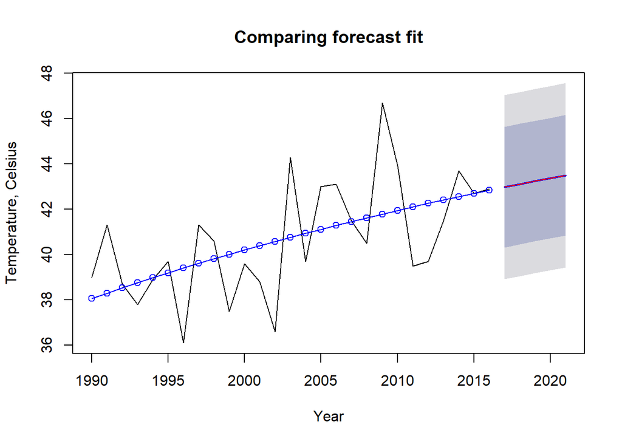

```r
# Use Holt Fit and damped
holtfit<- holt(ts, initial="optimal", h=5, damped = TRUE)

plot(holtfit, ylab="Temperature, Celsius", xlab= "Year", main="Comparing forecast fit")
lines(fitted(holtfit), col="blue", type="o")
lines(holtfit$mean, col="red")
```

```r
# Finding AICc
holtfit$model
```

```
## Damped Holt's method
##
## Call:
##  holt(y = ts, h = 5, damped = TRUE, initial = "optimal")
##
##   Smoothing parameters:
##     alpha = 8e-04
##     beta  = 1e-04
##     phi   = 0.98
##
##   Initial states:
##     l = 37.8249
##     b = 0.2432
##
##   sigma:  2.0741
##
##      AIC     AICc      BIC
## 140.3819 144.5819 148.1570
```